# Generalized Linear Models IV

Chelsea Parlett-Pelleriti

## Time Series Data

Time Series data are **repeated measurements** collected over time from the same system/subject

## Repeated Measures with MEMs

When the number of repeated measurements is small (e.g. pre/post/follow up for a psychology intervention) we can use Mixed Effect Models!

## Repeated Measures with MEMs

```r
# mem with interaction of treatment and time
repeated_mlm <- lmer(Outcome ~ Treatment * Time +
                       (1 + Time | Participant),
                     data = rt_data)

summary(repeated_mlm)
```

```
Linear mixed model fit by REML ['lmerMod']
Formula: Outcome ~ Treatment * Time + (1 + Time | Participant)
   Data: rt_data

REML criterion at convergence: 13724.7

Scaled residuals:
    Min      1Q  Median      3Q     Max
-2.9099 -0.5381  0.0003  0.5243  3.3140

Random effects:
 Groups      Name        Variance Std.Dev. Corr
 Participant (Intercept) 57.44040 7.5789
             Time         0.05631 0.2373   0.06
 Residual                 0.96553 0.9826
Number of obs: 3000, groups:  Participant, 1000

Fixed effects:
                        Estimate Std. Error t value
(Intercept)             49.05630    0.34656 141.550
TreatmentTreatment       0.22623    0.48865   0.463
Time                     0.04587    0.03293   1.393
TreatmentTreatment:Time  0.33615    0.04644   7.239

Correlation of Fixed Effects:
            (Intr) TrtmnT Time
TrtmntTrtmn -0.709
Time        -0.152  0.108
TrtmntTrt:T  0.108 -0.152 -0.709
```

## Repeated Measures with MEMs

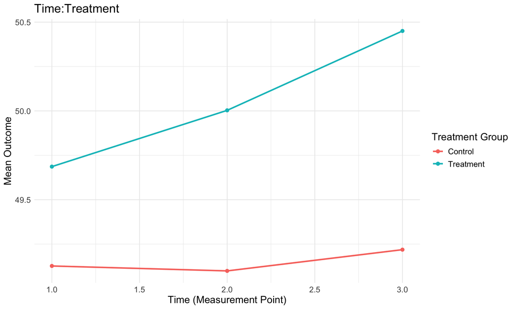

## Time Series

But often, we have *many* more observations. We can break these time series down into 3 components:

- **seasonal**: variation in value due to repeated patterns over time (e.g. day of week, day of year, day of month, time of day)
- **trend**: changes over time in the value
- **noise**: variation in the value not due to seasonality or trend

## Time Series Decomposition

$$Y_t = Tr_t + S_t + \epsilon_t$$

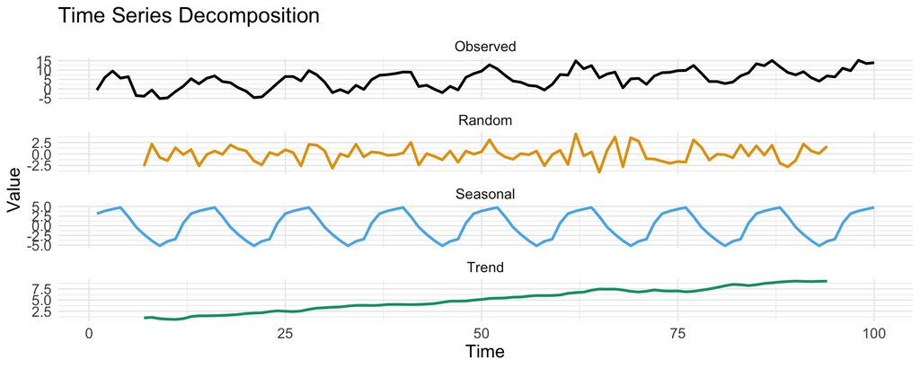

## Autocorrelation and Partial Autocorrelation

💡 with MCMC samples, we noted **autocorrelation** in our chains because each sample in the chain was conditioned on the previous sample

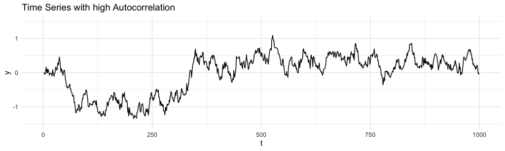

## Autocorrelation

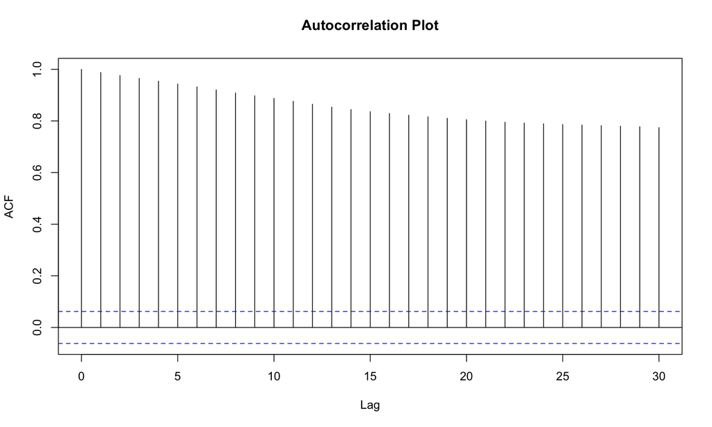

## Autocorrelation

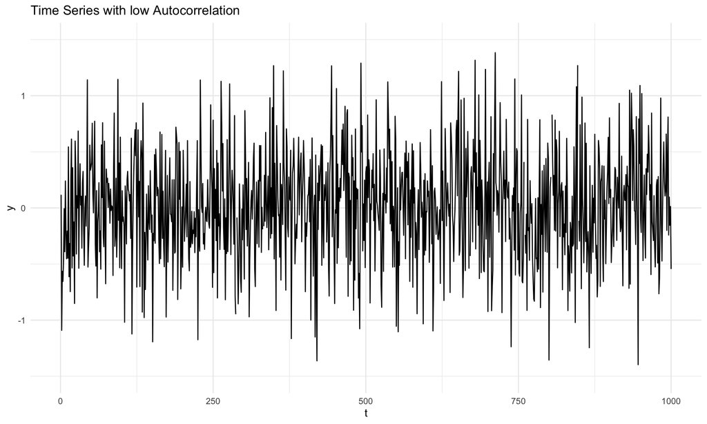

## Autocorrelation

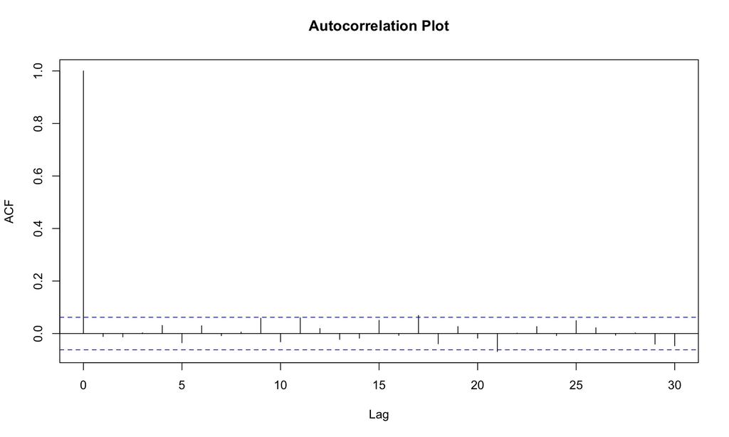

## Partial Autocorrelation

$$y_t = \phi_{21} y_{t-1} + \phi_{22} y_{t-2} + \epsilon_t$$

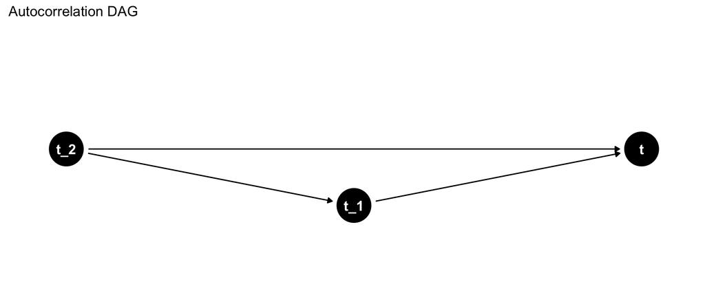

## Partial Autocorrelation

$$\text{pacf} = \frac{cov(y_t,y_{t-2} | y_{t-1})}{\sqrt{var(y_t| y_{t-1})* var(y_{t-2}| y_{t-1})}}$$

## Coefficient Interpretation in GLMs

**correlation:** the correlation between $x1$ and $y$

[figure not shown]

## Coefficient Interpretation in GLMs

**semi-partial correlation:** the correlation between $x1$ and $y$, after subtracting the influence of $x2$ on $x1$

[figure not shown]

## Coefficient Interpretation in GLMs

**partial correlation:** the correlation between $x1$ and $y$, after subtracting the influence of $x2$ on $x1$ and subtracting the influence of $x2$ on $y$

[figure not shown]

## Partial Autocorrelation

**partial autocorrelation:** the correlation between $y_t$ and $y_{t-2}$, after subtracting the influence of $y_{t-1}$ on $y_t$ and subtracting the influence of $y_{t-1}$ on $y_{t-2}$

[figure not shown]

## Partial Autocorrelation

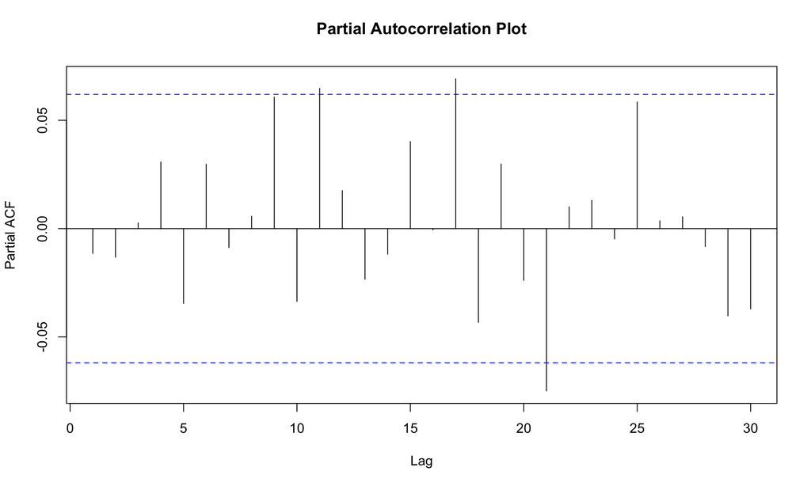

## Stationarity of a TS

1. $\mu$ is **constant**
2. $\sigma$ is **constant**
3. no **seasonality** (constant autocorrelation)

## Stationarity

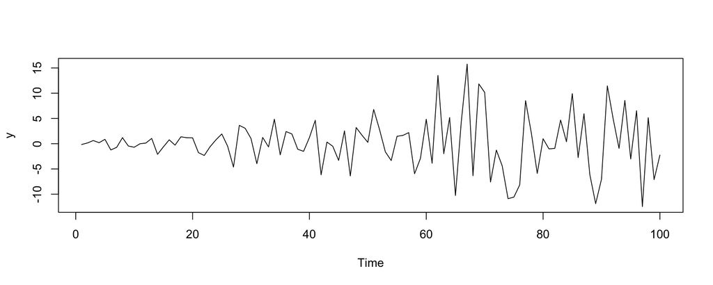

## Stationarity

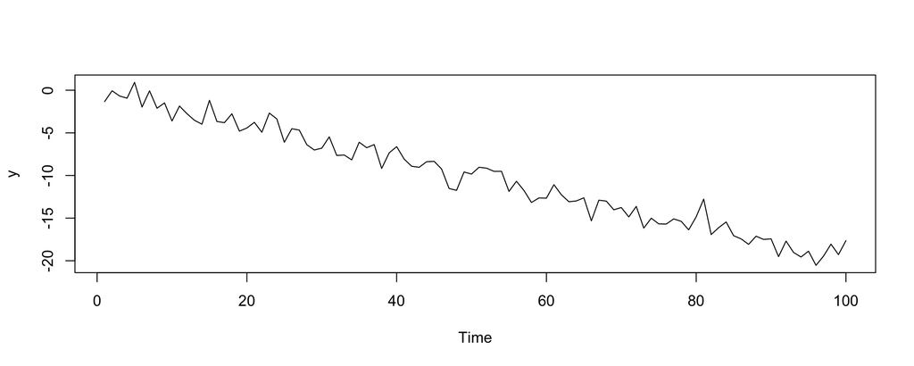

## Stationarity

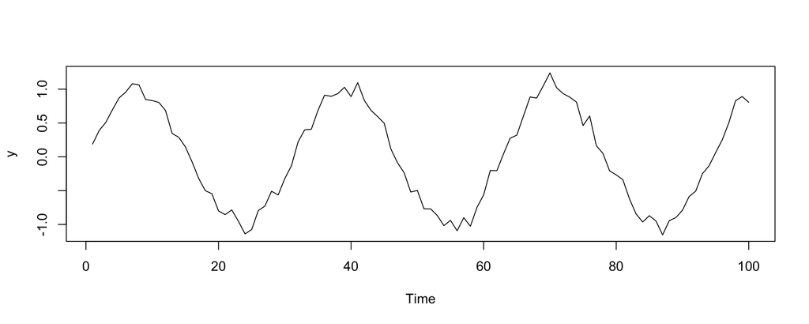

## Terminology: White Noise

1. $\mu$ is **0**
2. $\sigma$ is **constant**
3. no **autocorrelation**

## Are Non-Stationary Time Series Useless?

This time series is **not stationary**, is there anything we can do?

$$x_t = \beta_0 + \beta_1*t + \epsilon_t$$

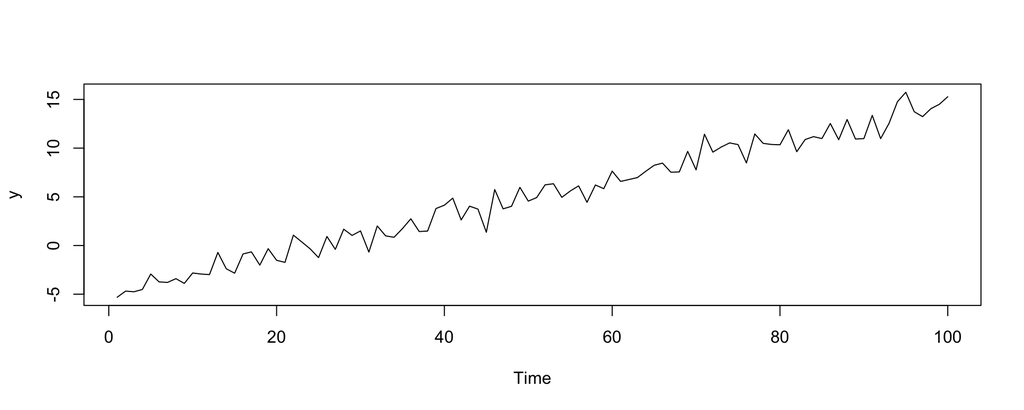

## Are Non-Stationary Time Series Useless?

💡 what if we used $x_t$ to create a new time series, $z_t$?

$$z_t = x_t - x_{t-1} = \\
\left[\beta_0 + \beta_1*t + \epsilon_t\right] - \left[\beta_0 + \beta_1*(t-1) + \epsilon_{t-1}\right] = \\
\beta_1 + (\epsilon_t - \epsilon_{t-1})$$

❓ what is the mean and variance of $z_t$?

## Are Non-Stationary Time Series Useless?

$$\mathbb{E}(z_t) = \mathbb{E}(\beta_1) + \mathbb{E}(\epsilon_t) - \mathbb{E}(\epsilon_{t-1}) = \beta_1$$

$$Var(z_t) = Var(\epsilon_t - \epsilon_{t-1}) = 2\sigma^2$$

## Notation: Lag/Backshift Operator

$B$ is the backshift operator represents a lagged version of a variable. For example:

$$By_t = y_{t-1} \\
B^2y_t = y_{t-2}$$

## AR Model

$$y = \beta_0 + \beta_1*x_1 + ...+ \beta_n * x_n + \epsilon$$

Review: in **GLM**s, we use various *predictors* (like age, height, income) to predict an *outcome* (like diabetes)

$$y_t = \beta_0 + \phi_1* y_{t-1} + \phi_2* y_{t-2} + ...+ \phi_n* y_{t-n} + \epsilon_t$$
In Time Series models we’re using *lagged observations* as predictors for our *current observation.*

## AR Model

An $AR(p)$ model is an **autoregressive model** of a **stationary** time series with the form:

$$y_t = \beta_0 + \underbrace{\sum_{i=1}^p \phi_iy_{t-i}}_{AR(p)} + \epsilon_t$$

where $\beta_0 = (1-\sum_{i=1}^{p}\phi_i)\mu$, and $\epsilon_t$ is a white-noise process.

## AR Model

How do you decide how many/which lags need to be in the model?

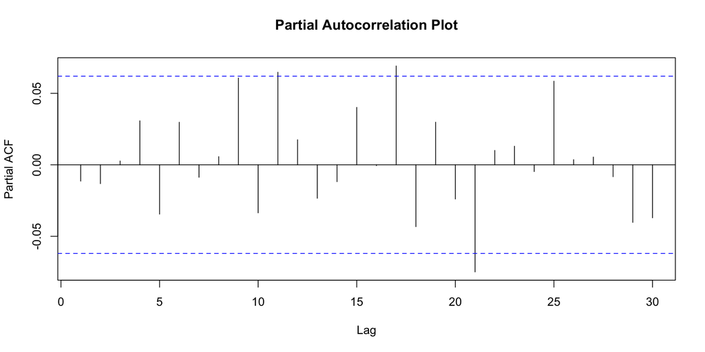

## AR Model

How do you decide how many/which lags need to be in the model?

💡note: if last year’s value $t-12$ gives us all the info we need about today, don’t bother including $t-24$

## AR Model in R

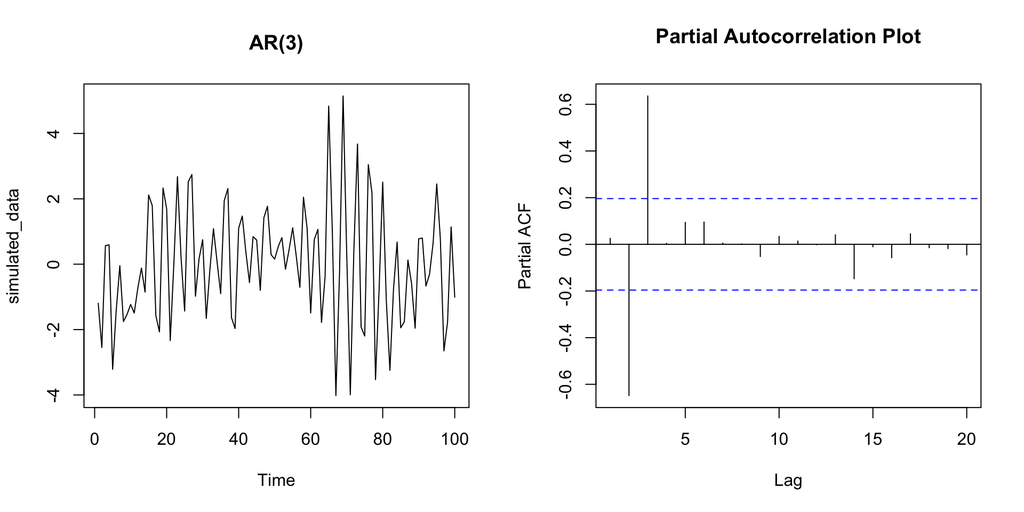

```r
par(mfrow = c(1, 2))
plot(simulated_data, main = "AR(3)")
pacf(simulated_data, main = "Partial Autocorrelation Plot")
```

## AR Model in R

```r
ar3 <- arima(simulated_data, order = c(3,0,0))
print(ar3)
```

```
Call:
arima(x = simulated_data, order = c(3, 0, 0))

Coefficients:
         ar1     ar2     ar3  intercept
      0.4945  -0.687  0.6803    -0.0427
s.e.  0.0741   0.054  0.0732     0.1886

sigma^2 estimated as 0.9663:  log likelihood = -141.67,  aic = 293.33
```

## AR Model in R

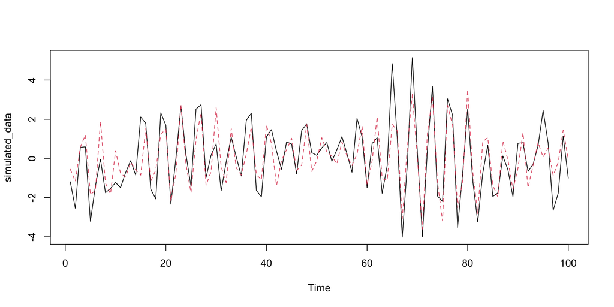

```r
ts.plot(simulated_data)
AR_fit <- simulated_data - residuals(ar3)
points(AR_fit, type = "l", col = 2, lty = 2)
```

## MA Model

An $MA(q)$ model is an **moving average model** of a **stationary** time series with the form

$$y_t = \beta_0 + \epsilon_t - \theta_1\epsilon_{t-1} - ...- \theta_q\epsilon_{t-q}$$

Thus, the current value predicted based on the *error* (white noise components) of previous time steps. You use your *past error* to help improve your *current prediction**.***

## MA Model

An $MA(q)$ model is an **moving average model** of a **stationary** time series with the form

$$y_t = \beta_0 + \epsilon_t - \theta_1\epsilon_{t-1} - ...- \theta_q\epsilon_{t-q}$$

The benefit: short term “shocks” come in and have short-term impact but decay **quickly**.

## MA Model

Proof with MA(1)…go to whiteboard!

$$y_t = \beta_0 + \epsilon_t - \theta_1\epsilon_{t-1}$$

## MA Model

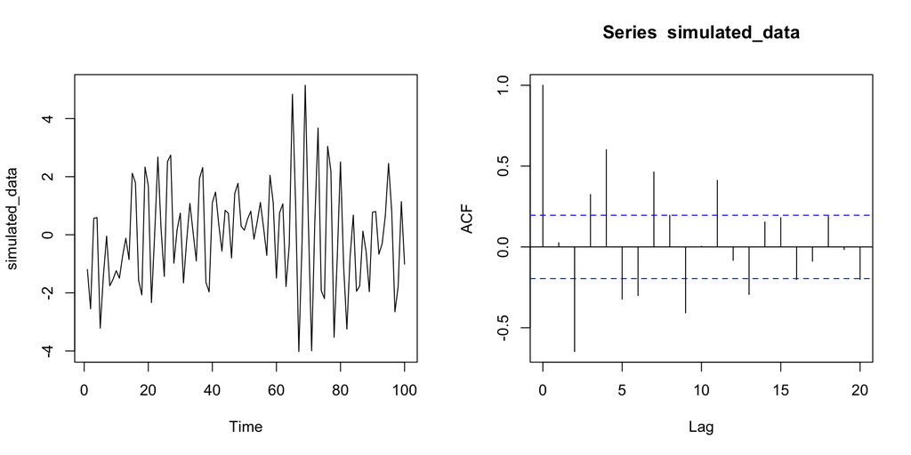

```r
par(mfrow = c(1, 2))
ts.plot(simulated_data)
acf(simulated_data)
```

## MA Model in R

```r
ma15 <- arima(simulated_data, order = c(0,0,15))
print(ma15)
```

```
Call:
arima(x = simulated_data, order = c(0, 0, 15))

Coefficients:
         ma1      ma2      ma3     ma4     ma5      ma6     ma7     ma8
      0.5762  -0.4246  -0.0070  0.7360  0.2235  -0.4281  0.1256  0.5307
s.e.  0.1004   0.1222   0.1505  0.1261  0.1668   0.1390  0.1640  0.1558
          ma9     ma10    ma11    ma12     ma13    ma14    ma15  intercept
      -0.1653  -0.3613  0.5099  0.2945  -0.2178  0.0306  0.2341    -0.0737
s.e.   0.1581   0.1691  0.1607  0.1651   0.1459  0.1655  0.1135     0.2368

sigma^2 estimated as 0.8511:  log likelihood = -137.93,  aic = 309.87
```

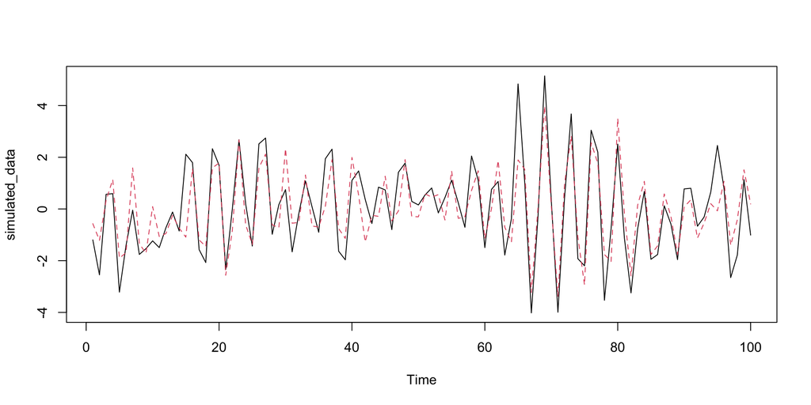

```r
ts.plot(simulated_data)
MA_fit <- simulated_data - residuals(ma15)
points(MA_fit, type = "l", col = 2, lty = 2)
```

## MA Model in R

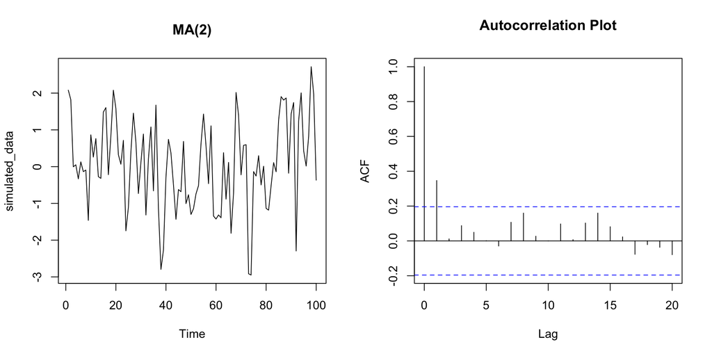

```r
par(mfrow = c(1, 2))
plot(simulated_data, main = "MA(2)")
acf(simulated_data, main = "Autocorrelation Plot")
```

## MA Model in R

```r
ma3 <- arima(simulated_data, order = c(0,0,3))
print(ma3)
```

```
Call:
arima(x = simulated_data, order = c(0, 0, 3))

Coefficients:
         ma1      ma2     ma3  intercept
      0.4198  -0.0222  0.0864     0.0617
s.e.  0.1010   0.1064  0.1127     0.1644

sigma^2 estimated as 1.236:  log likelihood = -152.62,  aic = 315.23
```

## MA Model in R

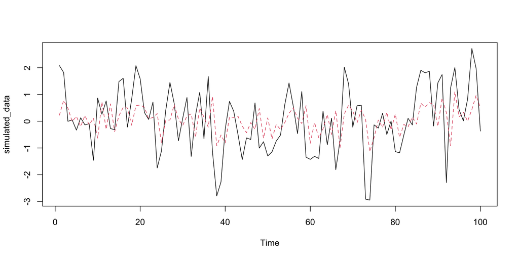

```r
ts.plot(simulated_data)
MA_fit <- simulated_data - residuals(ma3)
points(MA_fit, type = "l", col = 2, lty = 2)
```

## ARMA Model

An $ARMA(p,q)$ model has both an $AR(p)$ and $MA(q)$ component. An $ARMA(1,1)$ would look like:

$$y_t = \beta_0 + \underbrace{\phi_1y_{t-1}}_{AR} + \underbrace{\theta_1\epsilon_{t-1}}_{MA} + \epsilon_t$$

## ARMA Model in R

```r
ma3 <- arima(simulated_data, order = c(1,0,3))
print(ma3)
```

```
Call:
arima(x = simulated_data, order = c(1, 0, 3))

Coefficients:
         ar1     ma1      ma2     ma3  intercept
      0.2984  0.1228  -0.1441  0.1030     0.0649
s.e.  0.9962  0.9909   0.4388  0.1117     0.1710

sigma^2 estimated as 1.235:  log likelihood = -152.57,  aic = 317.15
```

## ARMA Model in R

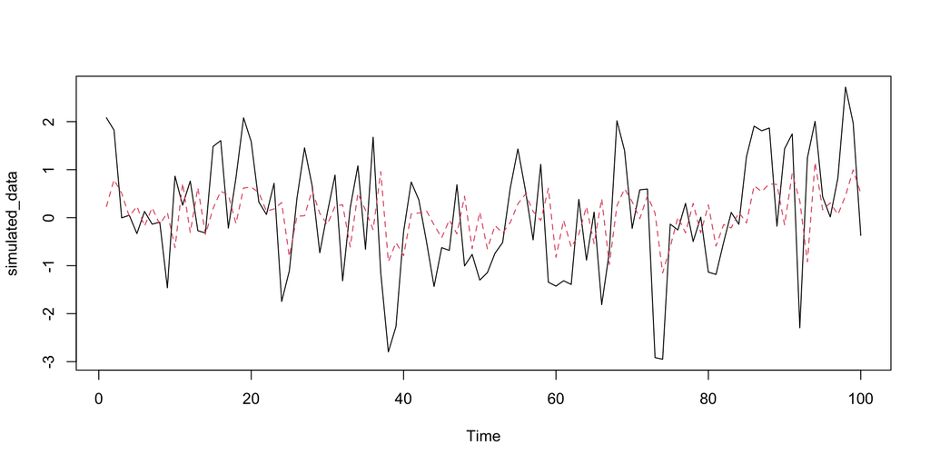

## ARIMA

ARIMA models have three important components:

- **AR**: autoregressive component
- **I**: integrated (stationarity)
- **MA**: moving average component

$ARIMA(p,d,q)$ refers to a model with an Auto Regressive component of $p$, an integrated component of $d$, and a Moving Average component of $q$

## ARIMA

$$x_t = \beta_0 + \beta_1*t + \epsilon_t$$

💡 what if we used $x_t$ to create a new time series, $z_t$?

$$z_t = x_t - x_{t-1} = \\
\left[\beta_0 + \beta_1*t + \epsilon_t\right] - \left[\beta_0 + \beta_1*(t-1) + \epsilon_{t-1}\right] = \\
\beta_1 + (\epsilon_t - \epsilon_{t-1})$$

## ARIMA

But what if $z_t$ is not stationary *either*?

$$w_t = z_t - z_{t-1}$$

And just keep going $d$ times until the time series *is* stationary.

## ARIMA

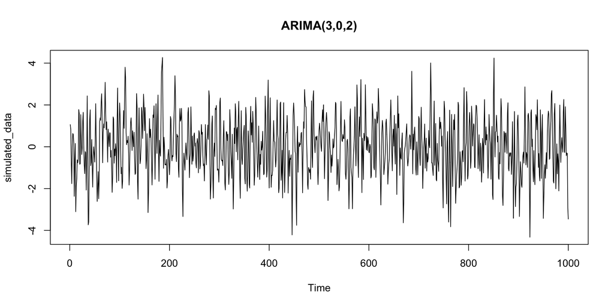

## ARIMA

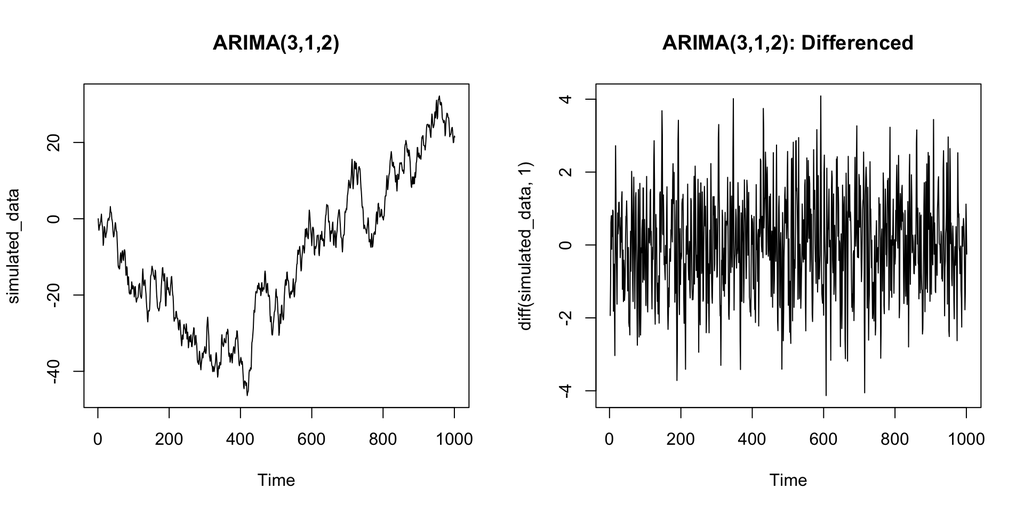

## ARIMA in R

```r
ma3 <- arima(simulated_data, order = c(1,1,3))
print(ma3)
```

```
Call:
arima(x = simulated_data, order = c(1, 1, 3))

Coefficients:
         ar1     ma1      ma2      ma3
      0.3560  0.6065  -0.3365  -0.2023
s.e.  0.1741  0.1700   0.1613   0.0354

sigma^2 estimated as 0.9149:  log likelihood = -1375.18,  aic = 2760.36
```

## ARIMA in R

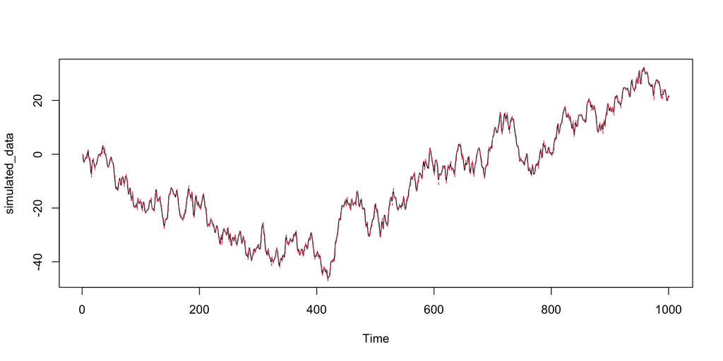

## Gaussian Processes for Time Series

**Gaussian**: a multivariate normal distribution

$$X \sim \mathcal{N}(\mu, \Sigma)$$

where $X = (x_1, x_2,..., x_p)$

$\Sigma$ tells you how the various components of $X$ are *related* (aka how they *covary*).

## Gaussian Processes for Time Series

let’s take $X$ and split it into two groups of data, $\begin{bmatrix}X\\Y \end{bmatrix}$

$$\begin{bmatrix}X\\Y \end{bmatrix} \sim \mathcal{N}(\mu, \Sigma) \\
\mu = \begin{bmatrix}\mu_X\\\mu_Y \end{bmatrix}; \sigma = \begin{bmatrix}\Sigma_{X,X} & \Sigma_{X,Y}\\\Sigma_{Y,X} & \Sigma_{Y,Y} \end{bmatrix}$$

- **marginalizing**: integrating over $X$ (aka summarizing over all values of $X$) , what is the distribution of $Y$ (or vice versa)
- **conditioning**: $X | Y$ given a value of $Y$, what is the distribution of $X$ (or vice versa)

[visual](https://distill.pub/2019/visual-exploration-gaussian-processes/)

## Gaussian Processes for Time Series

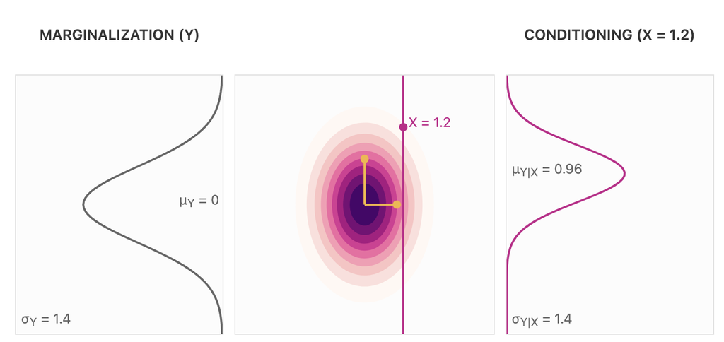

[visual](https://distill.pub/2019/visual-exploration-gaussian-processes/)

## Gaussian Processes for Time Series

What if, like in our other time series models, the items in our vector $\begin{bmatrix}X\\Y \end{bmatrix}$ are different time points?

$$\begin{bmatrix}X\\Y \end{bmatrix} = (x_1,x_2,...x_n, y_1, y_2, ..., y_n)$$

## Kernels

The **kernel** of a GP defines the *covariance* between any two time points.<sup>1</sup> In other words, how much *influence* the points have on each other.

[figure not shown]

from: https://distill.pub/2019/visual-exploration-gaussian-processes/

[^1]: if you remember SVMs, we talked about kernels there too! A kernel was a function that told you the similarity between two data points.

## Kernels

$$\Sigma = Cov(x,x') = k(x,x')$$

For example:

$$k(x,x') = \sigma^2 e^{- \frac{(x-x')^2}{2l}}$$

where $l$ and $\sigma$ are hyperparameter that you choose.

and I spend so much of my day choosing them…istg

## Kernels

We could use $k(x,x')$ to “fill out” the covariance matrix $\Sigma$ which tells us how each data point influences (or *covaries with*) each other data point.

## Kernel Simulation

Let’s say we want to look at 100 data points at $t = 0, t = 1, ...., t = 99$. The **kernel** gives us information about how these 100 time points *covary*.

Using the squared exponential kernel we talked about before, we can generate a few different 100-point time series with:

- $\mu = 0$ (for convenience)
- $\Sigma =\sigma^2 e^{- \frac{(x-x')^2}{2l}}$

## Kernel Simulation

Knowing $\mu$ and $\Sigma$ we can sample from a $\mathcal{N}(0,\Sigma)$ distribution.

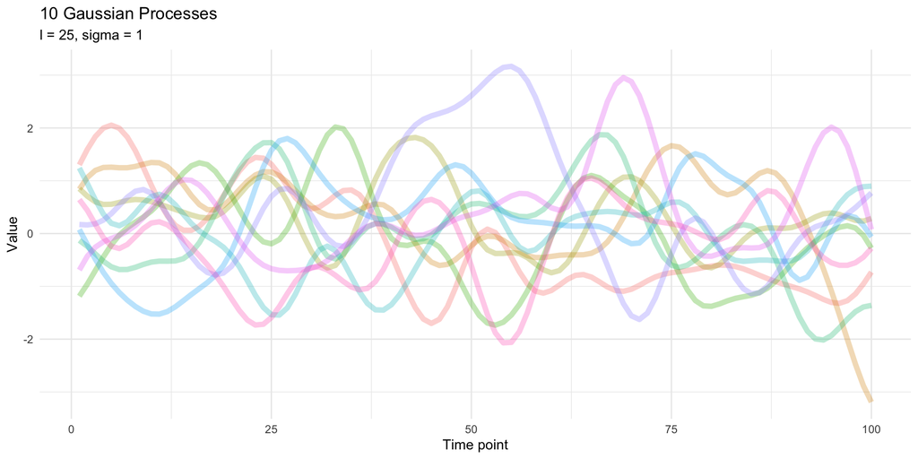

## Kernel Simulation

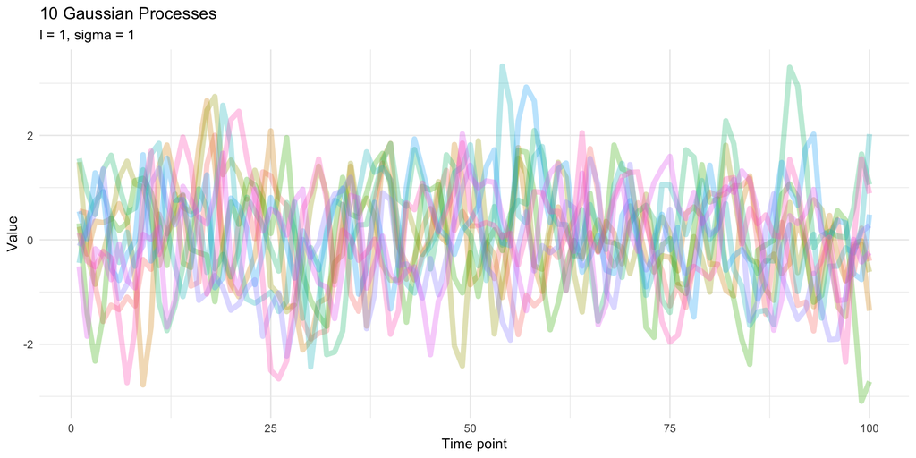

## Conditioning on Observed Data

Alone, the **kernel** acts as a *prior* that encodes our assumptions about the *shape* of the GP. Now, we incorporate the observed data by **conditioning** on it.

[figure not shown]

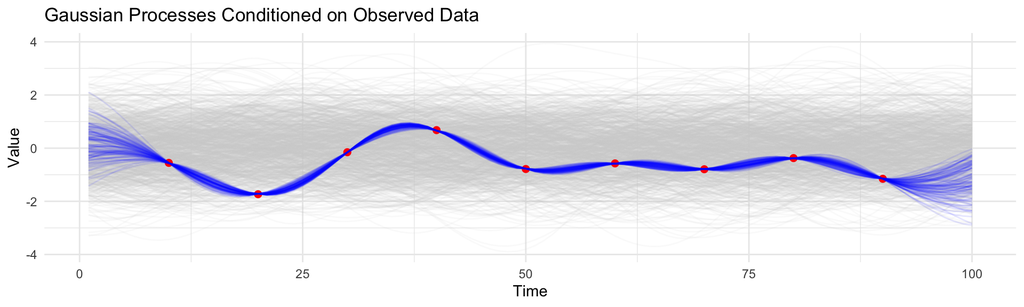

## Conditioning on Observed Data

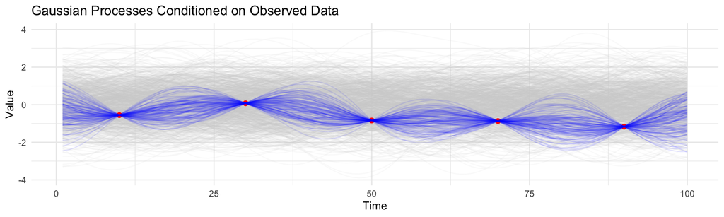

## Seasonal GP Kernels

[figure not shown]

## Gaussian Processes in R

```r
library(kernlab)
# Generate synthetic time series data
set.seed(540)
time <- seq(0, 10, length.out = 100)
y <- sin(time) + rnorm(100, sd = 0.2)

# Fit a Gaussian Process model using the radial basis function kernel
gp_model <- gausspr(time, y, kernel = "rbfdot", var = 0.1, variance.model = TRUE)

# Predict using the fitted Gaussian Process model
time_test <- seq(0, 14, length.out = 1000)
y_pred <- predict(gp_model, time_test)
y_up <- y_pred + 2*predict(gp_model, time_test, type="sdeviation")
y_low <- y_pred -2*predict(gp_model, time_test, type="sdeviation")
```

## Gaussian Processes in R

```
Using automatic sigma estimation (sigest) for RBF or laplace kernel
```

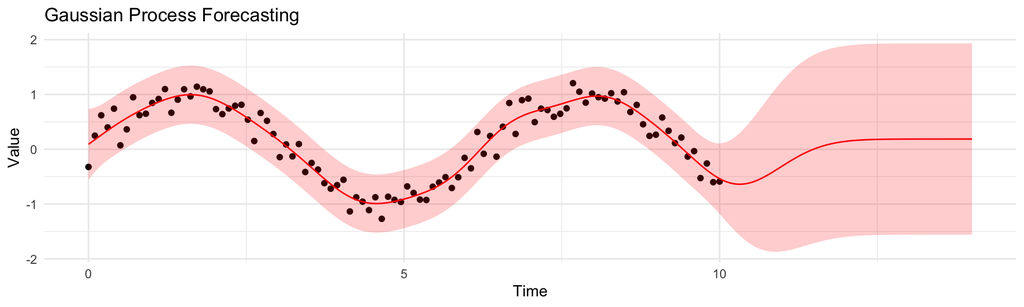